# Diez pruebas, ningún efecto: una introducción a las pruebas múltiples

Autor/a

Jake Bowers — EGAP Learning Days, Santiago de Chile

Fecha de publicación

30 de julio de 2026

## La situación

Imaginemos que evaluamos un programa social en 100 hogares: la mitad, asignada al azar, recibe el programa. Como el programa podría afectar muchas dimensiones de la vida, medimos diez variables de resultado: ingreso, empleo, asistencia escolar, salud, confianza en los vecinos, participación cívica, ahorro, seguridad percibida, consumo y satisfacción con la vida. Al final del estudio hacemos una prueba de hipótesis por cada resultado y reportamos cuáles dieron un valor p menor que 0.05.

Cada prueba individual promete equivocarse poco: si el programa no tiene efecto sobre ese resultado, la probabilidad de declarar un “efecto significativo” por puro azar es del 5%. La pregunta de este documento es otra: si el programa no tiene efecto sobre **ninguno** de los diez resultados, ¿cuál es la probabilidad de que **al menos una** de las diez pruebas declare un efecto? La intuición dice “5%, igual que antes”. La respuesta correcta es cerca del 40%.

Para verlo, vamos a construir un mundo donde sabemos con certeza que el programa no hace nada — porque nosotros mismos generamos los datos — y luego vamos a ver qué producen las pruebas en ese mundo.

## Un mundo donde el programa no hace nada

Cada hogar tiene, para cada variable, dos **resultados potenciales**: el resultado que mostraría si recibiera el programa, $y(1)$, y el resultado que mostraría si no lo recibiera, $y(0)$. “El programa no hace nada” tiene una traducción exacta en este lenguaje: $y(1) = y(0)$ para cada hogar y cada resultado. Construimos ese mundo directamente:

```r
set.seed(20260751) ## semilla maestra: fija Y0 y la asignación del primer experimento

N <- 100 ## hogares
K <- 10 ## variables de resultado

outcome_names <- c(
  "ingreso", "empleo", "asistencia", "salud", "confianza",
  "participacion", "ahorro", "seguridad", "consumo", "satisfaccion"
)

## Resultados potenciales: Y0 bajo control, Y1 bajo tratamiento.
## "El programa no hace nada" es literalmente Y1 = Y0,
## para cada hogar y cada resultado.
Y0 <- matrix(rnorm(N * K), nrow = N, dimnames = list(NULL, outcome_names))
Y1 <- Y0
```

La hipótesis nula — el programa no cambia nada para nadie — es verdadera por construcción, para los diez resultados a la vez. Ahora asignamos el tratamiento al azar (50 hogares tratados, 50 de control) y observamos, para cada hogar, el resultado potencial que le corresponde: $Y_{obs} = Z \cdot y(1) + (1 - Z) \cdot y(0)$.

```r
Z <- sample(rep(c(0, 1), N / 2)) ## asignación completamente aleatoria

## Observamos Y1 en los tratados y Y0 en los controles.
## Como Y1 = Y0, la asignación no cambia nada de lo que vemos.
Yobs <- Z * Y1 + (1 - Z) * Y0
dat <- data.frame(Z = factor(Z), Yobs)
```

## Un experimento, diez pruebas

Hacemos lo que haría el equipo de evaluación: una prueba por resultado. Usamos dos procedimientos distintos para mostrar que el problema no viene de una prueba en particular. `oneway_test()` del paquete `coin` compara medias usando la distribución de permutación: re-sortea la asignación 5000 veces y pregunta qué tan extrema resulta la estadística observada entre esos re-sorteos. `lm_robust()` del paquete `estimatr` estima la diferencia de medias con errores estándar HC2 y una aproximación normal. Ambos están justificados por la asignación aleatoria — el primero la usa directamente, el segundo la aproxima.

```r
p_oneway <- sapply(outcome_names, function(v) {
  pvalue(oneway_test(reformulate("Z", v),
    data = dat,
    distribution = approximate(nresample = 5000)
  ))
})

p_lm <- sapply(outcome_names, function(v) {
  est <- tidy(lm_robust(reformulate("Z", v), data = dat))
  est$p.value[est$term == "Z1"]
})

tabla1 <- data.frame(
  resultado = outcome_names,
  p_oneway = round(p_oneway, 3),
  p_lm_robust = round(p_lm, 3),
  significativo = ifelse(p_lm <= 0.05, "*", "")
)
kable(tabla1, row.names = FALSE)
```

| resultado | p_oneway | p_lm_robust | significativo |
| --- | --- | --- | --- |
| ingreso | 0.619 | 0.613 |  |
| empleo | 0.953 | 0.950 |  |
| asistencia | 0.256 | 0.274 |  |
| salud | 0.008 | 0.010 | * |
| confianza | 0.503 | 0.500 |  |
| participacion | 0.534 | 0.543 |  |
| ahorro | 0.749 | 0.755 |  |
| seguridad | 0.156 | 0.157 |  |
| consumo | 0.463 | 0.452 |  |
| satisfaccion | 0.570 | 0.573 |  |

Miren la fila de `salud`: p = 0.01 con ambas pruebas.[^1] Si este fuera un estudio real, el informe diría “el programa mejoró la salud (p < 0.05)” — y quizás el resumen ejecutivo solo mencionaría ese resultado. Pero nosotros sabemos que el programa no hizo nada: construimos `salud` con $y(1) = y(0)$ para cada hogar. Las dos pruebas coinciden casi exactamente, porque el problema no está en la prueba. Está en cuántas preguntas le hicimos a los datos.

## La tasa de error por familia (FWER)

Primero en palabras. Cuando hacemos una sola prueba con nivel de significancia $\alpha = 0.05$, el 5% es la probabilidad de un falso positivo **en esa prueba**. Cuando hacemos diez pruebas, el conjunto de las diez es una **familia**, y la pregunta relevante para el lector del informe es: ¿cuál es la probabilidad de que la familia entera produzca **al menos un** falso positivo? Esa probabilidad se llama la **tasa de error por familia** (*family-wise error rate*, FWER).

Ahora con un poco de álgebra. Supongamos que las $K$ pruebas fueran independientes y todas las hipótesis nulas fueran verdaderas. Cada prueba “acierta” (no rechaza) con probabilidad $1 - \alpha$: con $\alpha = 0.05$, acierta el 95% de las veces. ¿Con qué probabilidad aciertan las dos primeras a la vez? Como son independientes, multiplicamos: $0.95 \times 0.95 \approx 0.90$. Cada prueba adicional vuelve a multiplicar por 0.95, así que después de $K$ pruebas la probabilidad de que **todas** acierten es $(1 - \alpha)^K$ — un número que se encoge con cada prueba que agregamos. Y “al menos un falso positivo” es exactamente lo contrario de “todas aciertan”, así que su probabilidad es uno menos eso:

$$\text{FWER} = 1 - (1 - \alpha)^K.$$

Con $\alpha = 0.05$ y $K = 10$, eso da $1 - 0.95^{10}$ = 0.401. De vuelta a las palabras: un equipo que evalúa diez resultados de un programa sin ningún efecto tiene cerca de un 40% de probabilidad de “descubrir” algo. Con veinte resultados, la probabilidad llega a 0.64. La curva crece rápido:

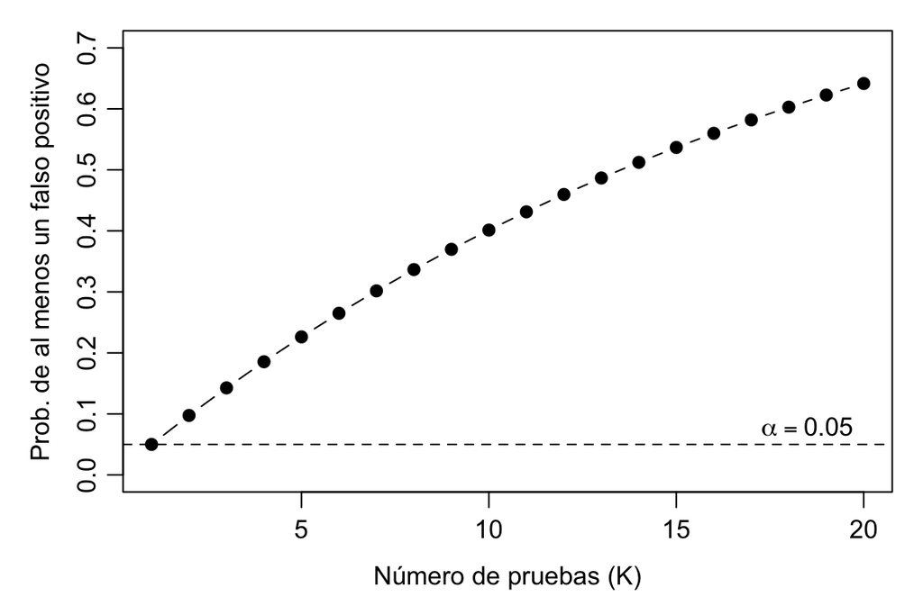

En un experimento real los resultados suelen estar correlacionados entre sí, y entonces la fórmula $1 - (1-\alpha)^K$ es solo una aproximación. Por eso no nos quedamos con el álgebra: simulamos.

## La simulación: repetimos el experimento 1000 veces

En nuestro mundo construido, la única fuente de azar es la asignación del tratamiento — exactamente la fuente de azar que justifica las dos pruebas. Así que dejamos los resultados potenciales `Y0` y `Y1` fijos y re-sorteamos la asignación $B = 1000$ veces, aplicando cada vez la misma ecuación de observación. En cada repetición corremos las diez pruebas con cada procedimiento y guardamos los valores p.

```r
run_experiment <- function() {
  ## Re-sorteamos la asignación y volvemos a observar; Y0 y Y1 quedan fijos.
  Z_nuevo <- sample(rep(c(0, 1), N / 2))
  d <- data.frame(Z = factor(Z_nuevo), Z_nuevo * Y1 + (1 - Z_nuevo) * Y0)
  p_ow <- sapply(outcome_names, function(v) {
    pvalue(oneway_test(reformulate("Z", v),
      data = d,
      distribution = approximate(nresample = 5000)
    ))
  })
  p_lm <- sapply(outcome_names, function(v) {
    est <- tidy(lm_robust(reformulate("Z", v), data = d))
    est$p.value[est$term == "Z1"]
  })
  rbind(oneway = p_ow, lm_robust = p_lm)
}

set.seed(20260731) ## semilla de la simulación
B <- 1000
sims <- replicate(B, run_experiment()) ## dimensiones: 2 procedimientos x K x B
```

Antes de mirar el FWER, verifiquemos que cada prueba individual cumple su promesa. Para cada resultado, calculamos la proporción de las 1000 repeticiones en que esa prueba rechazó con $p \leq 0.05$:

```r
rechazos_ow <- rowMeans(sims["oneway", , ] <= 0.05)
rechazos_lm <- rowMeans(sims["lm_robust", , ] <= 0.05)
kable(
  data.frame(
    resultado = outcome_names,
    oneway_test = round(rechazos_ow, 3),
    lm_robust = round(rechazos_lm, 3)
  ),
  row.names = FALSE
)
```

| resultado | oneway_test | lm_robust |
| --- | --- | --- |
| ingreso | 0.047 | 0.048 |
| empleo | 0.054 | 0.054 |
| asistencia | 0.047 | 0.045 |
| salud | 0.039 | 0.041 |
| confianza | 0.048 | 0.047 |
| participacion | 0.054 | 0.054 |
| ahorro | 0.051 | 0.052 |
| seguridad | 0.063 | 0.063 |
| consumo | 0.044 | 0.046 |
| satisfaccion | 0.054 | 0.052 |

Cada número estima una proporción con $B = 1000$ repeticiones, así que trae un error de simulación (error estándar Monte Carlo) de $\sqrt{0.05 \times 0.95 / 1000} \approx 0.007$. Todas las tasas están donde deben estar: cerca del 5%. Prueba por prueba, no hay nada roto.

Ahora la pregunta de la familia: ¿en qué proporción de las 1000 repeticiones **al menos una** de las diez pruebas rechazó?

```r
fwer_ow <- mean(apply(sims["oneway", , ] <= 0.05, 2, any))
fwer_lm <- mean(apply(sims["lm_robust", , ] <= 0.05, 2, any))
c(oneway_test = fwer_ow, lm_robust = fwer_lm)
```

```
oneway_test   lm_robust
      0.398       0.399
```

El FWER estimado es 0.4 con `oneway_test()` y 0.4 con `lm_robust()` (error estándar Monte Carlo $\approx 0.015$), consistente con el valor teórico de 0.401 para pruebas independientes. Este es el contraste que importa: **cada fila de la tabla anterior dice 5%, y sin embargo la familia se equivoca el 40% de las veces.** En cuatro de cada diez evaluaciones de un programa que no hace nada, el informe puede decir “encontramos un efecto significativo” sin que nadie haya hecho trampa.

## La corrección: una línea de código

Los procedimientos de comparaciones múltiples ajustan los valores p para que la promesa del 5% aplique a la familia entera y no a cada prueba por separado (Bretz et al. 2011). El más simple es Bonferroni: comparar cada valor p con $\alpha / K$ en lugar de $\alpha$. El procedimiento de Holm hace lo mismo paso a paso y rechaza al menos tanto como Bonferroni, así que usamos Holm. En R es una línea: `p.adjust(p, method = "holm")`.

Repetimos el cálculo del FWER, ahora ajustando los diez valores p dentro de cada repetición antes de preguntar si alguno queda bajo 0.05:

```r
fwer_holm_ow <- mean(apply(sims["oneway", , ], 2, function(p) {
  any(p.adjust(p, method = "holm") <= 0.05)
}))
fwer_holm_lm <- mean(apply(sims["lm_robust", , ], 2, function(p) {
  any(p.adjust(p, method = "holm") <= 0.05)
}))
c(oneway_test = fwer_holm_ow, lm_robust = fwer_holm_lm)
```

```
oneway_test   lm_robust
      0.036       0.036
```

Con el ajuste de Holm, el FWER estimado baja a 0.036 y 0.036 — por debajo del 5% prometido. La corrección no es gratis: exigir valores p más pequeños significa menos potencia para detectar efectos reales cuando existen. Ese costo es una razón para declarar pocas hipótesis primarias, o para agrupar resultados en índices, en lugar de probar todo lo que se midió. Cuando la familia es muy grande, controlar una tasa distinta — la proporción esperada de falsos descubrimientos entre los rechazos (FDR) — puede ser un objetivo más razonable que el FWER (Benjamini y Hochberg 1995).

## ¿Qué tiene esto que ver con la transparencia?

El cálculo del 40% supone algo que casi nunca se cumple: que el lector ve las diez pruebas. Si el informe solo menciona `salud`, el lector no puede saber que fue una prueba entre diez, y el valor p de 0.01 parece evidencia fuerte. El problema tampoco requiere mala fe: basta con que las decisiones de análisis — qué resultados probar, cómo definirlos, qué subgrupos mirar — se tomen después de ver los datos (Gelman y Loken 2013).

El plan de pre-análisis responde exactamente a esto. Declarar por adelantado cuáles son las hipótesis primarias, cómo se define cada resultado, y qué corrección por pruebas múltiples se aplicará hace visible el tamaño de la familia. La garantía del FWER es una promesa sobre la familia completa; solo significa algo para el lector que puede ver la familia completa. Eso es lo que el registro del diseño le entrega.

## Referencias

Benjamini, Yoav, y Yosef Hochberg. 1995. «Controlling the false discovery rate: a practical and powerful approach to multiple testing». *Journal of the Royal Statistical Society* 57 (1): 289-300. http://www.jstor.org/stable/2346101.

Bretz, Frank, Torsten Hothorn, y Peter Westfall. 2011. *Multiple comparisons using R*. CRC Press. https://doi.org/10.2307/1266041.

Gelman, Andrew, y Eric Loken. 2013. «The garden of forking paths: Why multiple comparisons can be a problem, even when there is no “fishing expedition” or “p-hacking” and the research hypothesis was posited ahead of time». https://sites.stat.columbia.edu/gelman/research/unpublished/p_hacking.pdf.

## Notas

[^1]: Elegimos la semilla maestra entre varias para que este primer experimento cayera dentro del ~40% de experimentos que producen al menos un falso positivo. La simulación de más abajo muestra con qué frecuencia ocurre; no es un caso raro.